# Analyse exploratoire du jeu de données TP5_a25_clas_app

Engel CALON, Bastien CUVILLIER, Camille MILON

### TP5_a25_clas_app

Jeu de données dédié à la classification

#### Chargement des données

```r
if(!require(here)) install.packages("here")
library(here)

# Chemin vers les données
data_path <- here("src", "data", "TP5_a25_clas_app.txt")

# Lecture des données
clas_data <- read.table(
  data_path,
  header = TRUE,
  sep = " ",
  quote = "\"",
  stringsAsFactors = FALSE
)

# y as factor ?

# Aperçu
head(clas_data)
```

|  | X1 | X2 | X3 | X4 | X5 | X6 | X7 | X8 | X9 | X10 | X11 | X12 | X13 | X14 | X15 | X16 | X17 | X18 | X19 | X20 | X21 | X22 | X23 | X24 | X25 | X26 | X27 | X28 | X29 | … |
| --- | --- | --- | --- | --- | --- | --- | --- | --- | --- | --- | --- | --- | --- | --- | --- | --- | --- | --- | --- | --- | --- | --- | --- | --- | --- | --- | --- | --- | --- | --- |
| 1 | 1.0065163 | 8.6750334 | 6.517806 | 4.725858 | 7.6361937 | 5.3624877 | 3.217294 | 5.194903 | 7.2738925 | 2.1214876 | 9.7681143 | 9.5574562 | 7.0107806 | 0.7577793 | 0.6207946 | 0.6956207 | 4.146181 | 8.750419 | 6.4068662 | 4.701844 | 1.1050918 | -2.71176335 | 0.01698219 | 0.7911322 | -1.49603576 | 0.08458072 | 2.17780815 | -0.7011612 | 0.53388938 | … |
| 2 | 0.0120711 | 4.3749623 | 8.657823 | 7.504461 | 5.4604619 | 0.1137105 | 6.212600 | 4.259314 | 0.1762056 | 0.5387074 | 5.3587082 | 9.6390062 | 0.4633467 | 1.6912014 | 3.4553535 | 3.1012933 | 6.701397 | 2.375837 | 8.6310647 | 4.578065 | 1.4264938 | -4.06045700 | -1.35715824 | -0.6540935 | 2.45245323 | 1.08876355 | 0.81702696 | 2.3895946 | 0.28472005 | … |
| 3 | 9.0776259 | 7.7976941 | 3.317222 | 4.210158 | 1.4592378 | 8.7584238 | 6.660031 | 4.758888 | 9.0241533 | 6.7893226 | 3.9027049 | 3.3480768 | 0.1082771 | 4.0078361 | 0.1380423 | 7.0230667 | 2.518842 | 1.098063 | 6.7733134 | 1.969468 | 0.2536669 | -0.05611348 | 3.91971616 | 0.2423393 | -0.03891585 | 2.05741093 | 1.04652071 | 2.0421063 | 0.33978588 | … |
| 4 | 8.8484182 | 1.5368048 | 0.956349 | 3.930444 | 2.5525347 | 5.1040289 | 1.772311 | 7.734425 | 7.5995646 | 9.6437019 | 0.5160271 | 4.5905450 | 4.9415929 | 6.5543772 | 0.8480849 | 1.9416095 | 9.239710 | 1.775003 | 8.1698400 | 3.654105 | 1.2256927 | 0.12804884 | -2.61847184 | 0.5922751 | -2.16884465 | 3.19892622 | 1.13785365 | 0.3881808 | 0.13968452 | … |
| 5 | 8.1195943 | 0.9495641 | 7.587940 | 2.867081 | 3.0700142 | 7.9538826 | 3.357414 | 2.527090 | 1.9231717 | 5.3026342 | 9.9947285 | 6.2634006 | 5.1715226 | 5.6602500 | 5.6103612 | 0.5398744 | 8.044642 | 6.804860 | 1.7282031 | 7.442155 | 2.9061785 | -0.14371014 | -4.41916143 | 0.6626987 | 3.16920994 | 1.01321573 | 0.96622902 | -0.5436392 | 0.01698886 | … |
| 6 | 5.0232010 | 2.1951353 | 1.961125 | 9.440699 | 0.9423481 | 9.9233414 | 3.210135 | 3.931974 | 6.8297370 | 1.1300613 | 6.6209239 | 0.8738375 | 0.8343961 | 5.6419774 | 0.3073010 | 1.6517047 | 6.150500 | 3.094254 | 0.4130398 | 6.203104 | 0.4469921 | -1.58588347 | -0.59870557 | 0.5314587 | -3.00833648 | 0.29875272 | 0.09325412 | 1.1284189 | 0.22826771 | … |

Le jeu de données contient 50 variables explicatives (X1 à X50) et 1 variable cible (y).  
Types des variables :  
- de X1 à X45 : double  
- de X46 à X50 : entiers

#### Résumé statistique

```r
summary(clas_data)
```

```
       X1                X2                 X3               X4                X5
 Min.   :0.01207   Min.   :0.005073   Min.   :0.0101   Min.   :0.02937   Min.   :0.03252
 1st Qu.:2.19607   1st Qu.:2.357949   1st Qu.:2.5618   1st Qu.:2.48929   1st Qu.:2.55026
 Median :4.79331   Median :5.161358   Median :4.9633   Median :4.79802   Median :4.85185
 Mean   :4.83642   Mean   :4.985697   Mean   :4.9979   Mean   :4.94432   Mean   :5.02221
 3rd Qu.:7.45427   3rd Qu.:7.416399   3rd Qu.:7.5434   3rd Qu.:7.43191   3rd Qu.:7.58644
 Max.   :9.95576   Max.   :9.959118   Max.   :9.9855   Max.   :9.95242   Max.   :9.96811
       X6                X7                 X8                 X9              X10
 Min.   :0.01078   Min.   :0.008236   Min.   :0.000651   Min.   :0.0406   Min.   :0.005047
 1st Qu.:2.70829   1st Qu.:2.613129   1st Qu.:2.724983   1st Qu.:2.5684   1st Qu.:2.835021
 Median :4.98780   Median :5.007056   Median :5.068319   Median :5.0144   Median :5.331545
 Mean   :5.05447   Mean   :4.984620   Mean   :5.094669   Mean   :4.9961   Mean   :5.189575
 3rd Qu.:7.34911   3rd Qu.:7.469238   3rd Qu.:7.388489   3rd Qu.:7.4184   3rd Qu.:7.609352
 Max.   :9.96945   Max.   :9.993127   Max.   :9.991282   Max.   :9.9743   Max.   :9.985412
      X11               X12               X13                X14                X15
 Min.   :0.00534   Min.   :0.02812   Min.   :0.006671   Min.   :0.008314   Min.   :0.006095
 1st Qu.:2.32774   1st Qu.:2.49164   1st Qu.:2.294186   1st Qu.:2.515894   1st Qu.:2.572703
 Median :4.71040   Median :4.99546   Median :4.762223   Median :4.816043   Median :4.863636
 Mean   :4.85116   Mean   :4.96264   Mean   :4.783768   Mean   :4.885092   Mean   :4.951104
 3rd Qu.:7.44562   3rd Qu.:7.49222   3rd Qu.:7.086818   3rd Qu.:7.258616   3rd Qu.:7.434114
 Max.   :9.99473   Max.   :9.97917   Max.   :9.948114   Max.   :9.990162   Max.   :9.980701
      X16                X17                X18               X19               X20
 Min.   :0.004307   Min.   :0.006276   Min.   :0.02862   Min.   :0.02356   Min.   :0.01058
 1st Qu.:2.590090   1st Qu.:2.345850   1st Qu.:2.50610   1st Qu.:2.38417   1st Qu.:2.37357
 Median :4.894658   Median :4.624815   Median :5.03317   Median :4.91720   Median :4.79161
 Mean   :5.038190   Mean   :4.875331   Mean   :5.11035   Mean   :4.96650   Mean   :4.89294
 3rd Qu.:7.581866   3rd Qu.:7.393895   3rd Qu.:7.72478   3rd Qu.:7.37964   3rd Qu.:7.44211
 Max.   :9.995778   Max.   :9.982394   Max.   :9.95247   Max.   :9.99377   Max.   :9.98862
      X21                X22                 X23                X24               X25
 Min.   :-14.4979   Min.   :-13.57644   Min.   :-11.2242   Min.   :-5.8052   Min.   :-8.0729
 1st Qu.: -1.0763   1st Qu.: -2.27003   1st Qu.: -1.3410   1st Qu.:-0.4929   1st Qu.:-0.9704
 Median :  0.4735   Median : -0.06991   Median :  0.2890   Median : 0.5321   Median : 0.5364
 Mean   :  0.5797   Mean   : -0.10988   Mean   :  0.4003   Mean   : 0.6170   Mean   : 0.6935
 3rd Qu.:  2.0280   3rd Qu.:  2.08425   3rd Qu.:  2.0035   3rd Qu.: 1.6260   3rd Qu.: 2.2147
 Max.   : 19.9501   Max.   : 23.31376   Max.   : 22.1878   Max.   :11.5005   Max.   :10.9382
      X26                X27               X28                X29                X30
 Min.   :-13.0896   Min.   :-2.4349   Min.   :-12.2734   Min.   :-0.51546   Min.   :-16.6949
 1st Qu.: -0.9773   1st Qu.: 0.2301   1st Qu.: -1.4733   1st Qu.: 0.06746   1st Qu.: -1.5199
 Median :  0.5876   Median : 0.9910   Median :  0.2712   Median : 0.15713   Median :  0.3683
 Mean   :  0.5137   Mean   : 0.9695   Mean   :  0.2731   Mean   : 0.16486   Mean   :  0.3557
```

[output cut: 15 more lines]

```
 Max.   : 2.17266   Max.   :  9.2358   Max.   :10.6979   Max.   : 6.2195   Max.   :13.4610
      X41               X42               X43                X44               X45
 Min.   :-6.6894   Min.   :-7.9500   Min.   :-13.8354   Min.   :-9.9375   Min.   :-13.52192
 1st Qu.:-0.2349   1st Qu.:-1.0264   1st Qu.: -2.0856   1st Qu.:-1.5402   1st Qu.: -1.58159
 Median : 0.6046   Median : 0.3580   Median :  0.2949   Median : 0.3996   Median :  0.04961
 Mean   : 0.5305   Mean   : 0.3099   Mean   :  0.2612   Mean   : 0.3823   Mean   :  0.05805
 3rd Qu.: 1.2056   3rd Qu.: 1.7617   3rd Qu.:  2.3840   3rd Qu.: 2.2711   3rd Qu.:  1.67741
 Max.   : 5.2402   Max.   : 7.1570   Max.   : 19.0798   Max.   : 9.4111   Max.   :  8.64138
      X46              X47             X48              X49              X50              y
 Min.   : 0.000   Min.   : 0.00   Min.   : 0.000   Min.   : 0.000   Min.   : 0.00   Min.   :1.000
 1st Qu.: 2.000   1st Qu.: 2.00   1st Qu.: 2.000   1st Qu.: 2.000   1st Qu.: 2.00   1st Qu.:2.000
 Median : 4.000   Median : 3.00   Median : 3.000   Median : 4.000   Median : 3.00   Median :2.000
 Mean   : 3.864   Mean   : 3.66   Mean   : 3.594   Mean   : 3.862   Mean   : 3.69   Mean   :2.204
 3rd Qu.: 5.000   3rd Qu.: 5.00   3rd Qu.: 5.000   3rd Qu.: 5.000   3rd Qu.: 5.00   3rd Qu.:3.000
 Max.   :13.000   Max.   :12.00   Max.   :11.000   Max.   :10.000   Max.   :13.00   Max.   :3.000
```

```r
if(!require(psych)) install.packages("psych")
library(psych)
describe(clas_data)
```

|  | vars | n | mean | sd | median | trimmed | mad | min | max | range | skew | kurtosis | se |
| --- | --- | --- | --- | --- | --- | --- | --- | --- | --- | --- | --- | --- | --- |
| X1 | 1 | 500 | 4.84 | 2.96 | 4.79 | 4.81 | 3.94 | 0.01 | 9.96 | 9.94 | 0.04 | -1.27 | 0.13 |
| X2 | 2 | 500 | 4.99 | 2.87 | 5.16 | 4.97 | 3.72 | 0.01 | 9.96 | 9.95 | 0.01 | -1.18 | 0.13 |
| X3 | 3 | 500 | 5.00 | 2.88 | 4.96 | 4.99 | 3.67 | 0.01 | 9.99 | 9.98 | 0.03 | -1.20 | 0.13 |
| X4 | 4 | 500 | 4.94 | 2.92 | 4.80 | 4.92 | 3.74 | 0.03 | 9.95 | 9.92 | 0.06 | -1.21 | 0.13 |
| X5 | 5 | 500 | 5.02 | 2.92 | 4.85 | 5.02 | 3.72 | 0.03 | 9.97 | 9.94 | 0.02 | -1.22 | 0.13 |
| X6 | 6 | 500 | 5.05 | 2.83 | 4.99 | 5.07 | 3.45 | 0.01 | 9.97 | 9.96 | -0.04 | -1.13 | 0.13 |
| X7 | 7 | 500 | 4.98 | 2.88 | 5.01 | 4.98 | 3.63 | 0.01 | 9.99 | 9.98 | 0.01 | -1.16 | 0.13 |
| X8 | 8 | 500 | 5.09 | 2.83 | 5.07 | 5.10 | 3.48 | 0.00 | 9.99 | 9.99 | -0.02 | -1.12 | 0.13 |
| X9 | 9 | 500 | 5.00 | 2.89 | 5.01 | 4.98 | 3.62 | 0.04 | 9.97 | 9.93 | 0.04 | -1.19 | 0.13 |
| X10 | 10 | 500 | 5.19 | 2.87 | 5.33 | 5.23 | 3.52 | 0.01 | 9.99 | 9.98 | -0.10 | -1.13 | 0.13 |

[output cut: 41 more lines]

##### Variables X1 à X20

Les valeurs se situent principalement **entre 0 et 10**, avec une **moyenne autour de 5**.

La répartition semble **symétrique** et bien **centrée**, sans valeurs extrêmes marquées.

Données probablement simulées sur une même échelle …

##### Variables X21 à X45

Ces variables présentent une plage de valeurs beaucoup plus large, **parfois négatives** (ex: X21 min = -14.5, max = 19.95).

On observe plusieurs variables avec des **valeurs extrêmes** (en gros, celles dont les min et max dépassent largement les autres (ex: X22, X35, X32))

Ces variables nécessiteront probablement une standardisation ou une normalisation avant apprentissage.

##### Variables X46 à X50

Les variables X46 à X50 sont **entières** (valeurs discrètes entre 0 et 13) => variables catégorielles ordinales ou scores.

Leur distribution est relativement centrée autour de 3 à 5.

##### Variable cible y

y prend les valeurs 1, 2 et 3 => **3 classes**

Moyenne = 2.20, Médiane = 2, premier quartile = 2 => la **classe 2 semble majoritaire** (et la classe 1 la moins représentée ?)

```r
# Nombre de valeurs manquantes
colSums(is.na(clas_data))
```

```
 X1  X2  X3  X4  X5  X6  X7  X8  X9 X10 X11 X12 X13 X14 X15 X16 X17 X18 X19 X20 X21 X22 X23 X24 X25 X26 X27
  0   0   0   0   0   0   0   0   0   0   0   0   0   0   0   0   0   0   0   0   0   0   0   0   0   0   0
X28 X29 X30 X31 X32 X33 X34 X35 X36 X37 X38 X39 X40 X41 X42 X43 X44 X45 X46 X47 X48 X49 X50   y
  0   0   0   0   0   0   0   0   0   0   0   0   0   0   0   0   0   0   0   0   0   0   0   0
```

Aucune valeur manquante n’a été détectée.

#### Distributions

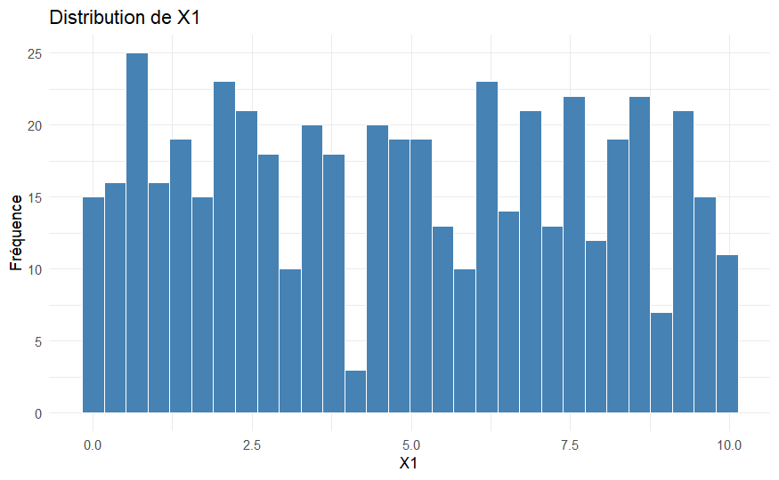

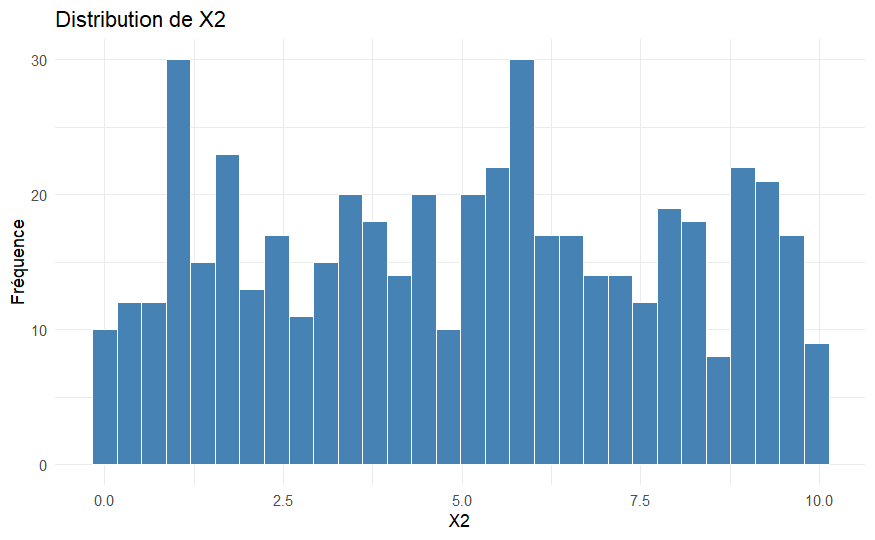

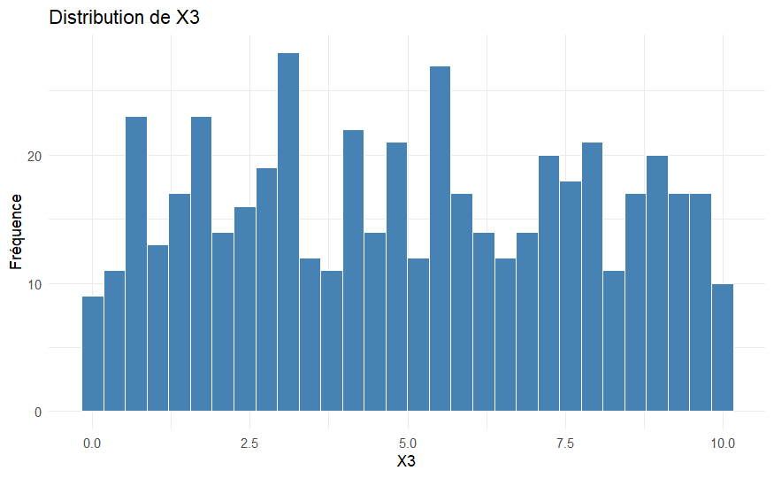

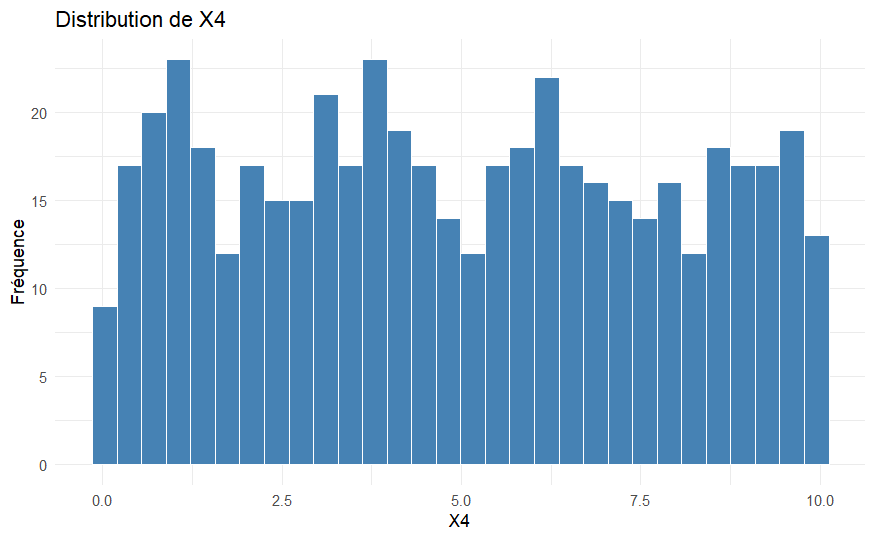

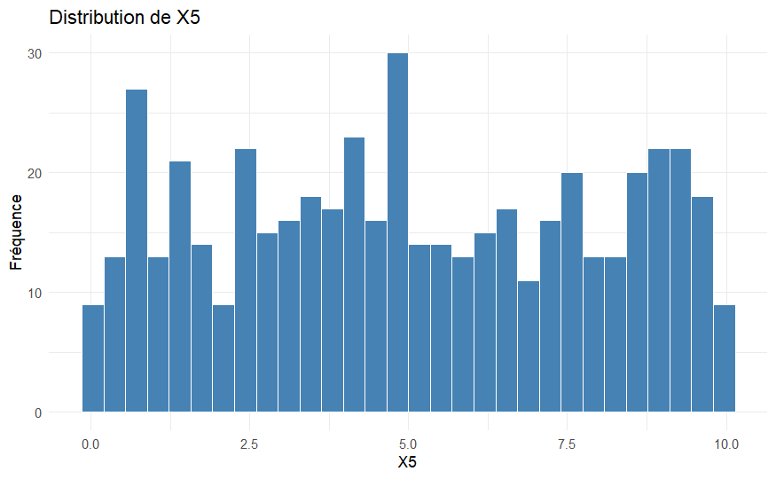

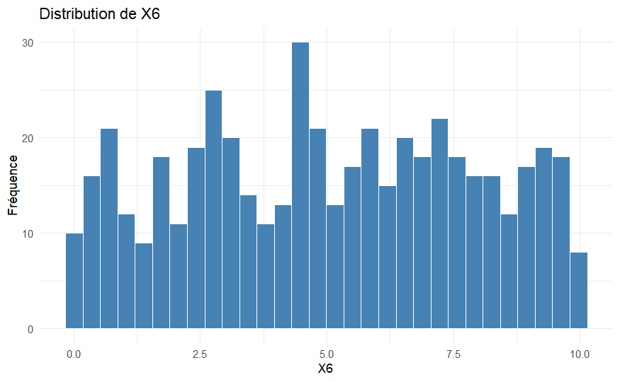

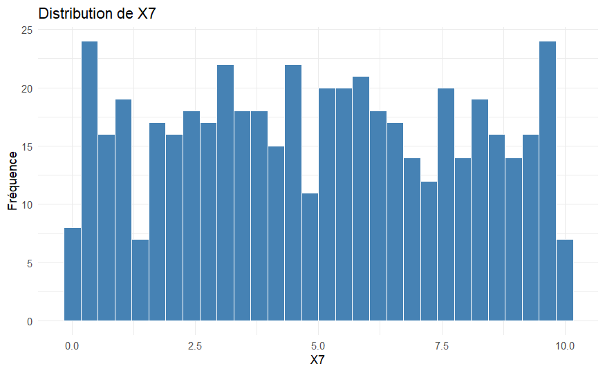

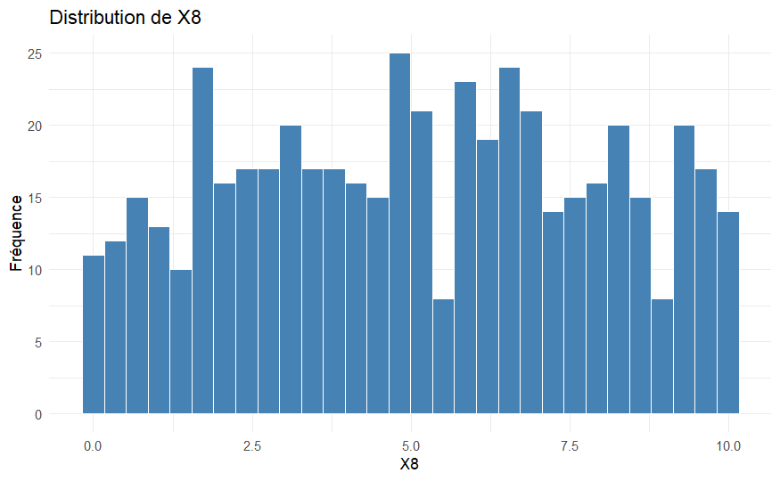

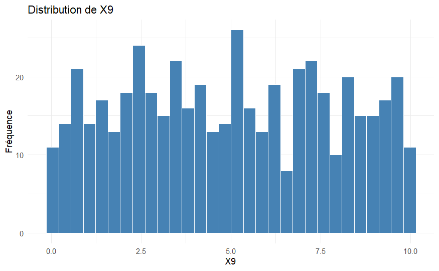

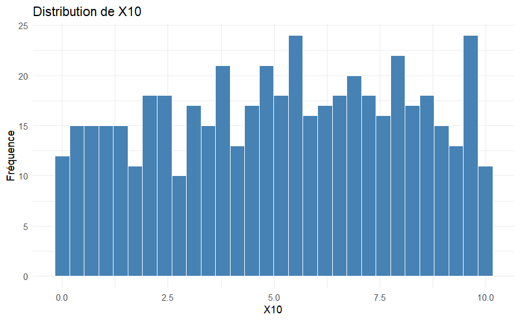

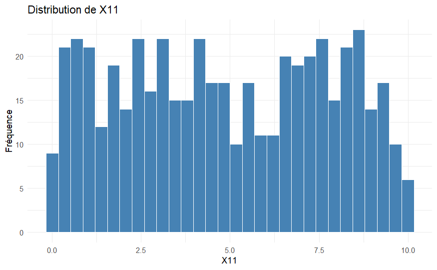

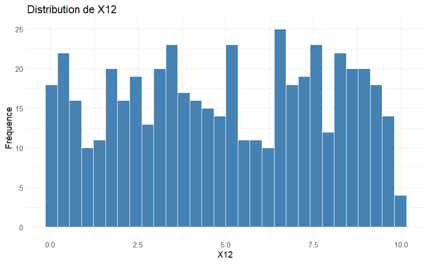

[38 more figures not shown]

```r
library(tidyverse)
# Histogrammes pour les premières variables
num_vars <- names(data)[sapply(data, is.numeric)]

# Exemple sur les 6 premières pour ne pas surcharger
for (var in head(num_vars, 50)) {
  print(
    ggplot(data, aes_string(x = var)) +
      geom_histogram(bins = 30, fill = "steelblue", color = "white") +
      labs(title = paste("Distribution de", var), x = var, y = "Fréquence") +
      theme_minimal()
  )
}
```

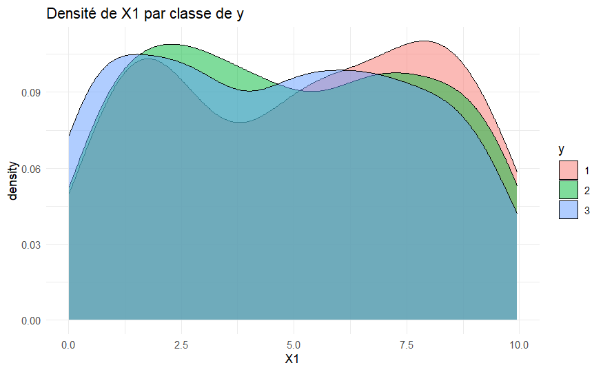

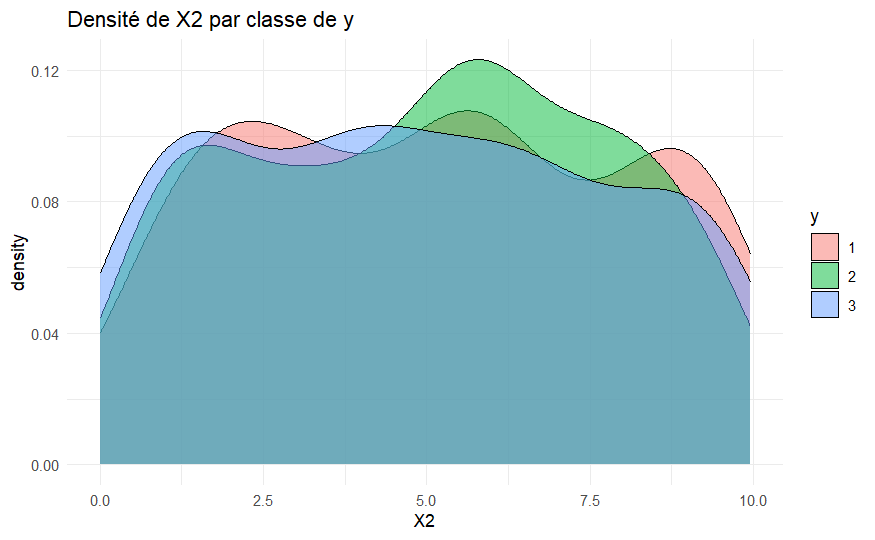

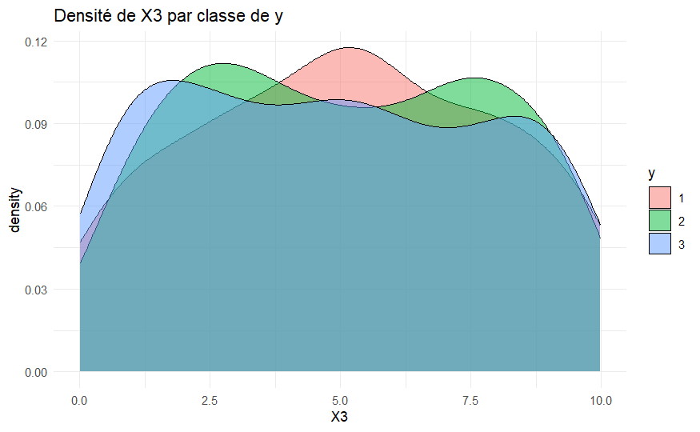

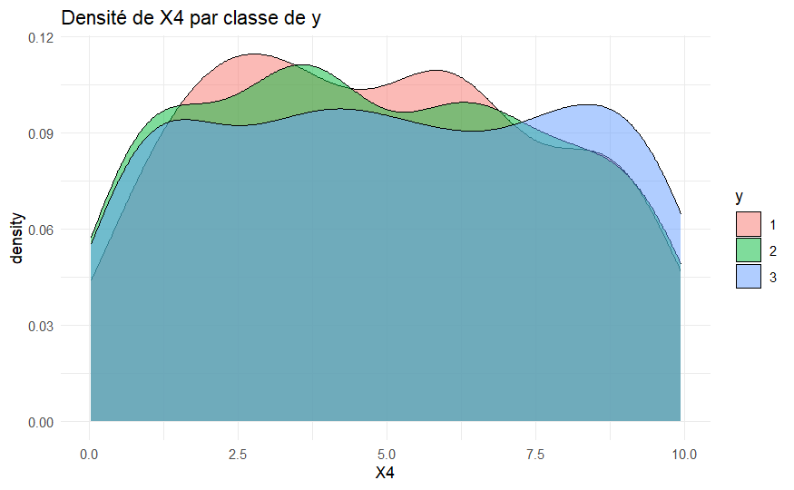

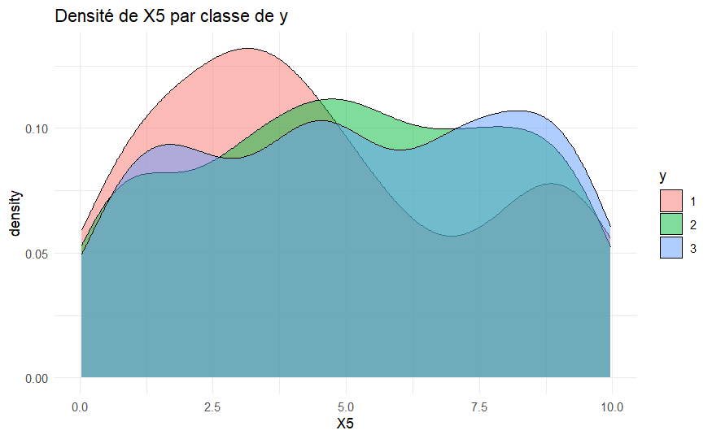

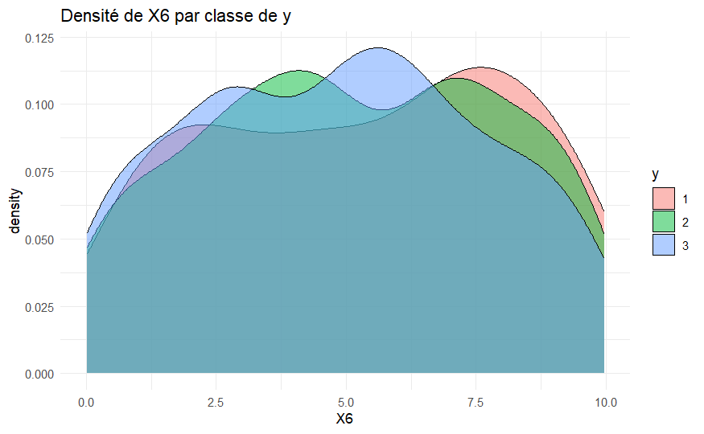

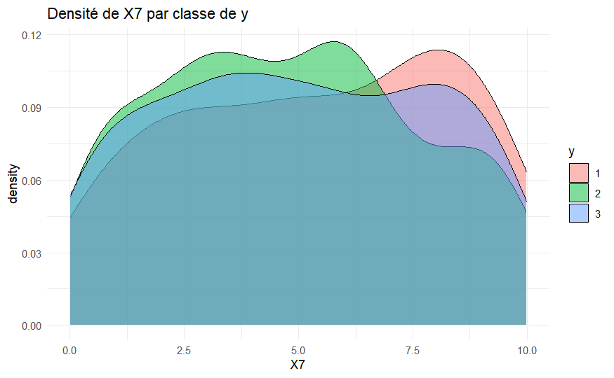

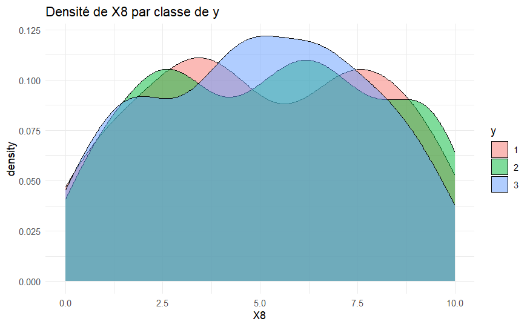

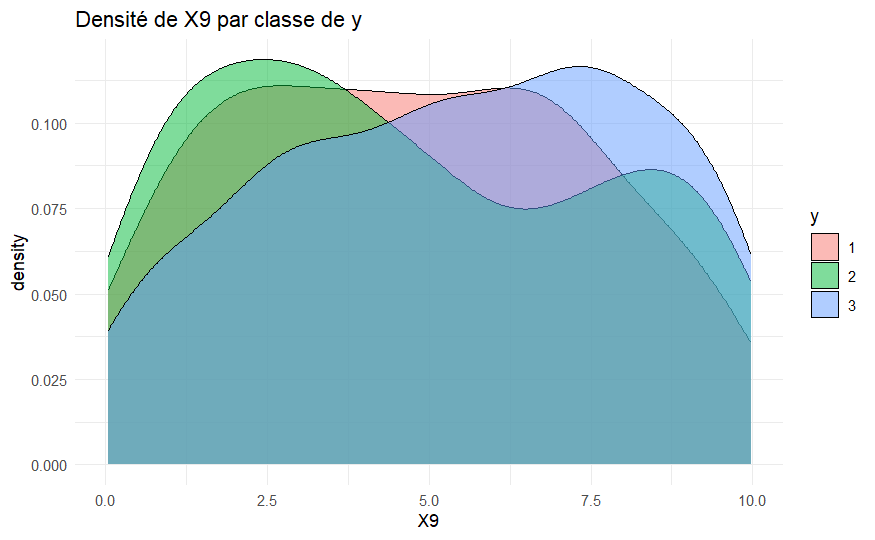

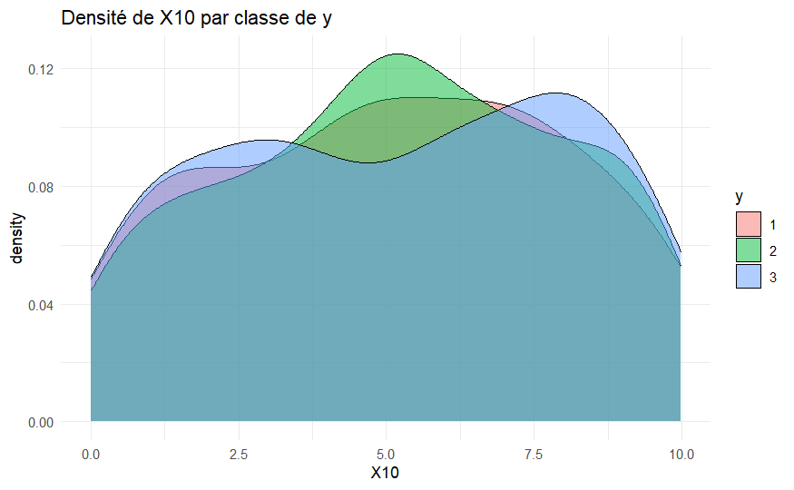

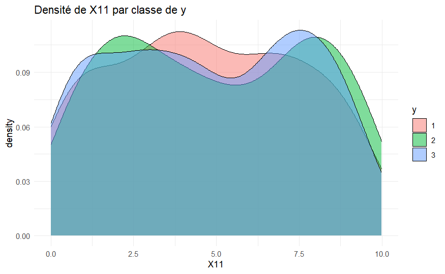

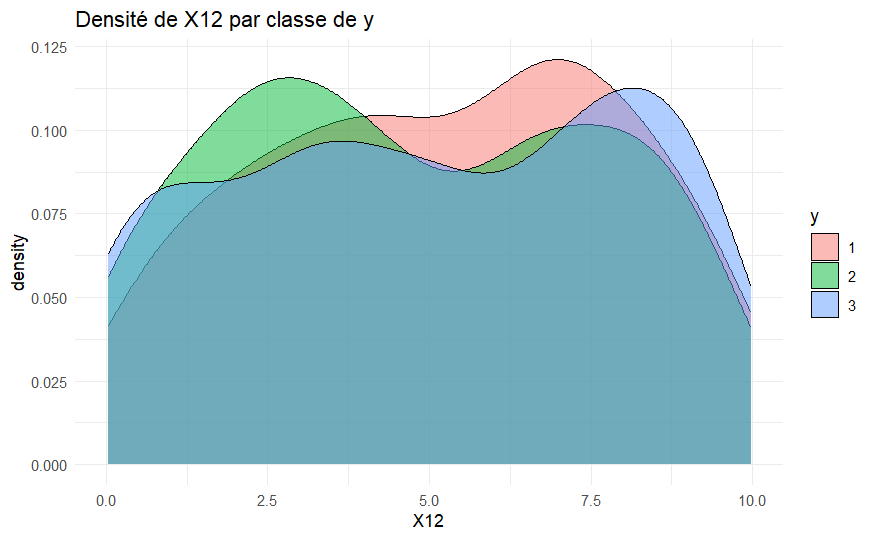

[38 more figures not shown]

```r
# Densités par classe (y)
for (var in head(num_vars, 50)) {
  print(
    ggplot(data, aes_string(x = var, fill = "y")) +
      geom_density(alpha = 0.5) +
      labs(title = paste("Densité de", var, "par classe de y")) +
      theme_minimal()
  )
}
```

##### Distributions

Les **variables X1 à X20** semblent suivre des **distributions aléatoires** : distributions relativement uniformes, sans concentration vraiment marquée autour d’une valeur, aucune asymétrie, etc => contribuent probablement peu à la séparation des classes (à vérifier)

Les **variables X21 à X50** semblent suivre des distributions **gaussiennes**. => se prêtent bien à des méthodes linéaires (reg. log., LDA, etc) => plus de potentiel discriminant  
Par ailleurs, les graphiques illustrent bien la présence de valeurs aberrantes (ex : X41) => standardisation (centrage/reduction) nécessaire

##### Densités par classe

De manière générale, les courbes de densité des classes se chevauchent fortement pour la majorité des variables. Cela signifie qu’aucune variable ne permet à elle seule de séparer nettement les classes => meilleurs résultats obtenus avec les variables X9, X12, X45, X46, X47, X48 et X49, bien que peu concluant

#### Corrélation

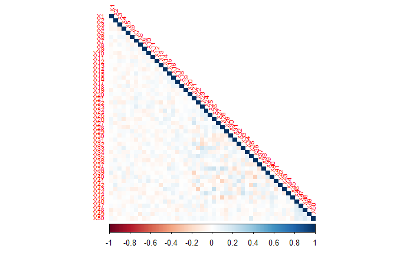

```r
library(corrplot)
# Calcul de la matrice de corrélation
corr_matrix <- cor(data[, num_vars])

# Visualisation
corrplot(corr_matrix, method = "color", type = "lower", tl.cex = 0.6, number.cex = 0.5)
```

On observe aucune forte corrélation entre les différentes variables.

#### Répartition des classes

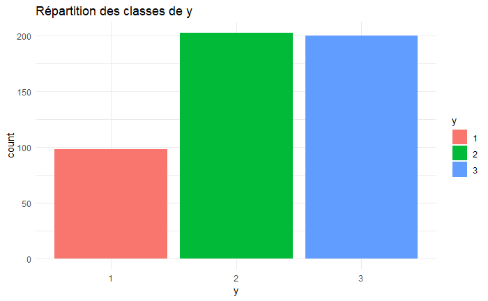

```r
ggplot(data, aes(x = y, fill = y)) +
  geom_bar() +
  labs(title = "Répartition des classes de y") +
  theme_minimal()
```

Cela confirme l’hypothèse selon laquelle la **classe 1 est sous-représentée** => pour les splits, il faudra donc faire attention de bien conserver la proportion de chaque classe !!!